# Click and drag belief elicitation interface for qualtrics

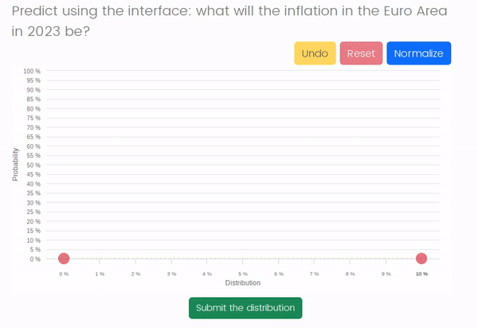

This is the Qualtrics JavaScript plugin for the **Click and Drag** *belief elicitation interface* presented by [Paolo Crosetto](https://paolocrosetto.wordpress.com/) and [Thomas De Haan](https://sites.google.com/view/thomas-de-haan). Details of the interface, a paper presenting its performance with respect to other interfaces, and oTee code are available on the [Click and Drag website](https://beliefelicitation.github.io/).

## Installation for Qualtrics XM

This plugin will work with all Qualtrics plans that allow you to use JavaScript. This will **not** work with a free account, and also with some paid account. Look into your Qualtrics plan to see if you have access to custom JavaScript for your survey items.

### Import the .qsf template file

To install the plugin, simply download and import the [.qsf template file](https://raw.githubusercontent.com/beliefelicitation/qualtrics/main/Click-and-drag_elicitation_builder_template.qsf) into qualtrics :

1. Download [here](https://raw.githubusercontent.com/beliefelicitation/qualtrics/main/Click-and-drag_elicitation_builder_template.qsf)
2. Navigate to the `Survey` tab and click `Tools`.

[figure not shown]

3. Select `Import/Export`.
4. Choose `Import survey`.
5. Click `Choose File` and browse your computer for the `.qsf`

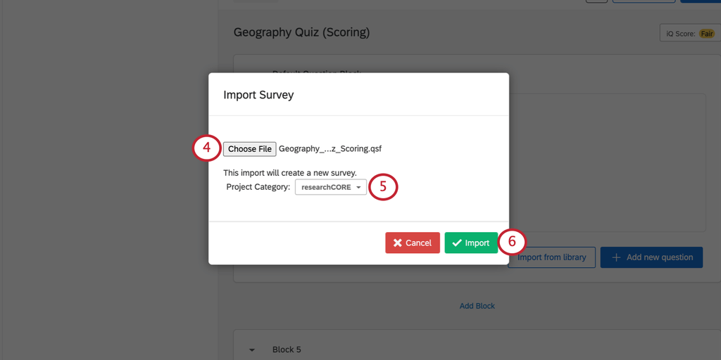

6. Select a `Project Category`.
7. Click `Import`.

### Custom the distribution graph

1. Click on the question block.
2. Click on Html View

You will find:

```html
Predict using the interface: what will the inflation in the Euro Area in 2023 be?
<div style="text-align: right;">
    <button id="undo"  class="btn  btn-warning"  disabled  type="button">Undo</button>
    <button id="reset" class="btn  btn-danger" disabled  type="button">Reset</button>
    <button id="normalize" class="btn btn-primary" style="color: #fff;"  type="button">Normalize</button>
</div>

<div id="draw" data-n_bins="11" data-min="0" data-step="1" data-x_axis_title="Distribution" data-y_axis_title="Probability" data-x_unit="%"></div>

<div class="mt-2" style="text-align: center;margin-left:50px">
 <a class="btn btn-success" id="SubmitDistribution">Submit the distribution</a>
</div>
```

To custom the distribution graph you just need to edit these parameters in the div line :

```html
<div id="draw" data-n_bins="11" data-min="0" data-step="1" data-x_axis_title="Distribution" data-y_axis_title="Probability" data-x_unit="%"></div>
```

| Parameter | Html variable | Value |
| --- | --- | --- |
| Number of bins | data-n_bins | 11 |
| Min value of the x axis | data-min | 0 |
| Step between bins | data-step | 1 |
| X axis Title | data-x_axis_title | Distribution |
| Y axis Title | data-y_axis_title | Probability |
| X axis unit | data-x_unit | % |

### Javascript code (not required for installation)

1. Click on the question block.

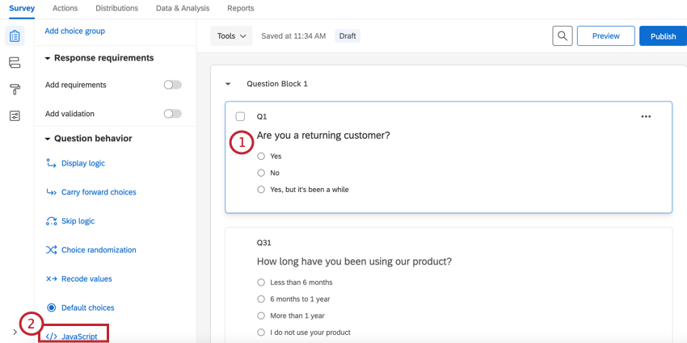

2. In the Question behavior section, select JavaScript.

### Libraries js/css (not required for installation)

To find where are the js/css scripts : 1. Navigate to the “Look and Feel” section of your survey, and click on the “Advanced” tab 2. Edit the “Header” section, you will find the libraries scripts and libraries styles

## Installation for Otree

https://www.otreehub.com/projects/beliefelicitation/